# Risk Factor Analysis

## Outcome Variable

**Outcome Variable:** whz

## Predictor Variables

**Intervention Variable:** gagebrth

**Adjustment Set:**

- arm
- sex
- W_mage
- meducyrs
- feducyrs
- hhwealth_quart
- single
- brthmon
- W_parity
- delta_W_mage
- delta_meducyrs
- delta_feducyrs
- delta_hhwealth_quart
- delta_single
- delta_brthmon
- delta_W_parity

## Stratifying Variables

The analysis was stratified on these variable(s):

- agecat
- studyid
- country

## Data Summary

| agecat | studyid | country | gagebrth | n_cell | n |
| --- | --- | --- | --- | --- | --- |
| Birth | ki1000108-CMC-V-BCS-2002 | INDIA | Full or late term | 54 | 87 |
| Birth | ki1000108-CMC-V-BCS-2002 | INDIA | Preterm | 10 | 87 |
| Birth | ki1000108-CMC-V-BCS-2002 | INDIA | Early term | 23 | 87 |
| Birth | ki1000108-IRC | INDIA | Full or late term | 213 | 328 |
| Birth | ki1000108-IRC | INDIA | Preterm | 32 | 328 |
| Birth | ki1000108-IRC | INDIA | Early term | 83 | 328 |
| Birth | ki1000109-EE | PAKISTAN | Full or late term | 0 | 1 |
| Birth | ki1000109-EE | PAKISTAN | Preterm | 1 | 1 |
| Birth | ki1000109-EE | PAKISTAN | Early term | 0 | 1 |
| Birth | ki1000304b-SAS-CompFeed | INDIA | Full or late term | 1 | 166 |
| Birth | ki1000304b-SAS-CompFeed | INDIA | Preterm | 151 | 166 |
| Birth | ki1000304b-SAS-CompFeed | INDIA | Early term | 14 | 166 |
| Birth | ki1017093c-NIH-Crypto | BANGLADESH | Full or late term | 6 | 23 |
| Birth | ki1017093c-NIH-Crypto | BANGLADESH | Preterm | 3 | 23 |
| Birth | ki1017093c-NIH-Crypto | BANGLADESH | Early term | 14 | 23 |
| Birth | ki1101329-Keneba | GAMBIA | Full or late term | 680 | 1401 |
| Birth | ki1101329-Keneba | GAMBIA | Preterm | 207 | 1401 |
| Birth | ki1101329-Keneba | GAMBIA | Early term | 514 | 1401 |
| Birth | ki1119695-PROBIT | BELARUS | Full or late term | 7071 | 13824 |
| Birth | ki1119695-PROBIT | BELARUS | Preterm | 468 | 13824 |
| Birth | ki1119695-PROBIT | BELARUS | Early term | 6285 | 13824 |
| Birth | ki1135781-COHORTS | GUATEMALA | Full or late term | 323 | 572 |
| Birth | ki1135781-COHORTS | GUATEMALA | Preterm | 78 | 572 |
| Birth | ki1135781-COHORTS | GUATEMALA | Early term | 171 | 572 |
| Birth | ki1135781-COHORTS | INDIA | Full or late term | 553 | 1229 |
| Birth | ki1135781-COHORTS | INDIA | Preterm | 259 | 1229 |
| Birth | ki1135781-COHORTS | INDIA | Early term | 417 | 1229 |
| Birth | ki1135781-COHORTS | PHILIPPINES | Full or late term | 1135 | 2874 |
| Birth | ki1135781-COHORTS | PHILIPPINES | Preterm | 579 | 2874 |
| Birth | ki1135781-COHORTS | PHILIPPINES | Early term | 1160 | 2874 |

[output cut: 69 more lines]

The following strata were considered:

- agecat: 24 months, studyid: ki1000108-CMC-V-BCS-2002, country: INDIA
- agecat: 24 months, studyid: ki1000108-IRC, country: INDIA
- agecat: 24 months, studyid: ki1017093c-NIH-Crypto, country: BANGLADESH
- agecat: 24 months, studyid: ki1066203-TanzaniaChild2, country: TANZANIA, UNITED REPUBLIC OF
- agecat: 24 months, studyid: ki1101329-Keneba, country: GAMBIA
- agecat: 24 months, studyid: ki1119695-PROBIT, country: BELARUS
- agecat: 24 months, studyid: ki1135781-COHORTS, country: GUATEMALA
- agecat: 24 months, studyid: ki1135781-COHORTS, country: INDIA
- agecat: 24 months, studyid: ki1135781-COHORTS, country: PHILIPPINES
- agecat: 24 months, studyid: kiGH5241-JiVitA-3, country: BANGLADESH
- agecat: 6 months, studyid: ki1000108-CMC-V-BCS-2002, country: INDIA
- agecat: 6 months, studyid: ki1000108-IRC, country: INDIA
- agecat: 6 months, studyid: ki1000109-EE, country: PAKISTAN
- agecat: 6 months, studyid: ki1000304b-SAS-CompFeed, country: INDIA
- agecat: 6 months, studyid: ki1017093c-NIH-Crypto, country: BANGLADESH
- agecat: 6 months, studyid: ki1066203-TanzaniaChild2, country: TANZANIA, UNITED REPUBLIC OF
- agecat: 6 months, studyid: ki1101329-Keneba, country: GAMBIA
- agecat: 6 months, studyid: ki1119695-PROBIT, country: BELARUS
- agecat: 6 months, studyid: ki1135781-COHORTS, country: GUATEMALA
- agecat: 6 months, studyid: ki1135781-COHORTS, country: INDIA
- agecat: 6 months, studyid: ki1135781-COHORTS, country: PHILIPPINES
- agecat: 6 months, studyid: kiGH5241-JiVitA-3, country: BANGLADESH
- agecat: Birth, studyid: ki1000108-CMC-V-BCS-2002, country: INDIA
- agecat: Birth, studyid: ki1000108-IRC, country: INDIA
- agecat: Birth, studyid: ki1000109-EE, country: PAKISTAN
- agecat: Birth, studyid: ki1000304b-SAS-CompFeed, country: INDIA
- agecat: Birth, studyid: ki1017093c-NIH-Crypto, country: BANGLADESH
- agecat: Birth, studyid: ki1101329-Keneba, country: GAMBIA
- agecat: Birth, studyid: ki1119695-PROBIT, country: BELARUS
- agecat: Birth, studyid: ki1135781-COHORTS, country: GUATEMALA
- agecat: Birth, studyid: ki1135781-COHORTS, country: INDIA
- agecat: Birth, studyid: ki1135781-COHORTS, country: PHILIPPINES
- agecat: Birth, studyid: kiGH5241-JiVitA-3, country: BANGLADESH

### Dropped Strata

Some strata were dropped due to rare outcomes:

- agecat: Birth, studyid: ki1000109-EE, country: PAKISTAN
- agecat: Birth, studyid: ki1000304b-SAS-CompFeed, country: INDIA
- agecat: Birth, studyid: ki1017093c-NIH-Crypto, country: BANGLADESH
- agecat: 24 months, studyid: ki1066203-TanzaniaChild2, country: TANZANIA, UNITED REPUBLIC OF

## Methods Detail

We’re interested in the causal parameters $E[Y_a]$ for all values of $a \in \mathcal{A}$. These parameters represent the mean outcome if, possibly contrary to fact, we intervened to set all units to have $A=a$. Under the randomization and positivity assumptions, these are identified by the statistical parameters $\psi_a=E_W[E_{Y|A,W}(Y|A=a,W)]$. In addition, we’re interested in the mean of $Y$, $E[Y]$ under no intervention (the observed mean). We will estimate these parameters by using SuperLearner to fit the relevant likelihood factors – $E_{Y|A,W}(Y|A=a,W)$ and $p(A=a|W)$, and then updating our likelihood fit using a joint TMLE.

For unadjusted analyses ($W=\{\}$), initial likelihoods were estimated using Lrnr_glm to estimate the simple $E(Y|A)$ and Lrnr_mean to estimate $p(A)$. For adjusted analyses, a small library containing Lrnr_glmnet, Lrnr_xgboost, and Lrnr_mean was used.

# Results Detail

## Results Plots

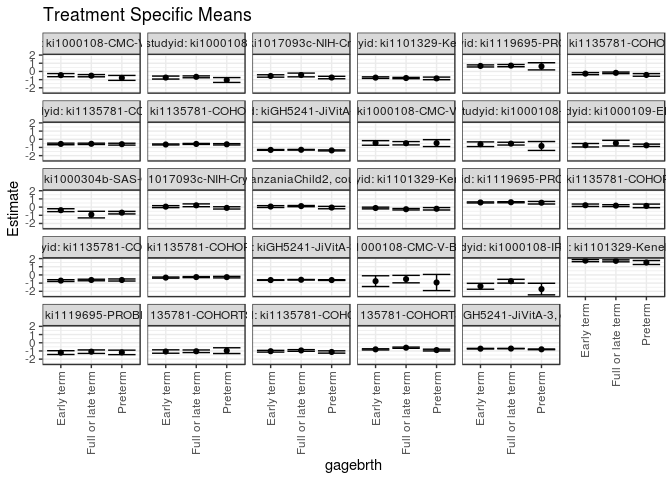

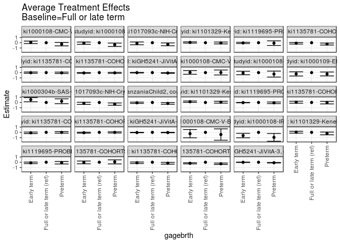

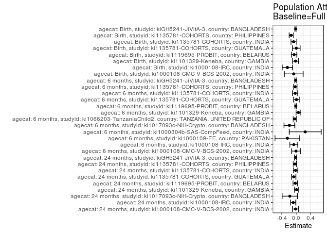

## Results Table

### Parameter: TSM

| agecat | studyid | country | intervention_level | baseline_level | estimate | ci_lower | ci_upper |
| --- | --- | --- | --- | --- | --- | --- | --- |
| Birth | ki1000108-CMC-V-BCS-2002 | INDIA | Full or late term | NA | -0.5093441 | -0.9630957 | -0.0555925 |
| Birth | ki1000108-CMC-V-BCS-2002 | INDIA | Preterm | NA | -0.9236694 | -1.9098144 | 0.0624757 |
| Birth | ki1000108-CMC-V-BCS-2002 | INDIA | Early term | NA | -0.7597309 | -1.4173098 | -0.1021521 |
| Birth | ki1000108-IRC | INDIA | Full or late term | NA | -0.7695301 | -1.0009205 | -0.5381398 |
| Birth | ki1000108-IRC | INDIA | Preterm | NA | -1.7267064 | -2.4350451 | -1.0183678 |
| Birth | ki1000108-IRC | INDIA | Early term | NA | -1.3858899 | -1.7461826 | -1.0255973 |
| Birth | ki1101329-Keneba | GAMBIA | Full or late term | NA | 1.7182764 | 1.5976659 | 1.8388869 |
| Birth | ki1101329-Keneba | GAMBIA | Preterm | NA | 1.5170001 | 1.2761746 | 1.7578257 |
| Birth | ki1101329-Keneba | GAMBIA | Early term | NA | 1.7449925 | 1.6133053 | 1.8766797 |
| Birth | ki1119695-PROBIT | BELARUS | Full or late term | NA | -1.0895441 | -1.3041079 | -0.8749803 |
| Birth | ki1119695-PROBIT | BELARUS | Preterm | NA | -1.1761595 | -1.4505480 | -0.9017710 |
| Birth | ki1119695-PROBIT | BELARUS | Early term | NA | -1.2027204 | -1.4336636 | -0.9717772 |
| Birth | ki1135781-COHORTS | GUATEMALA | Full or late term | NA | -1.0389071 | -1.1999087 | -0.8779054 |
| Birth | ki1135781-COHORTS | GUATEMALA | Preterm | NA | -0.9635464 | -1.3156790 | -0.6114138 |
| Birth | ki1135781-COHORTS | GUATEMALA | Early term | NA | -1.0691510 | -1.2764064 | -0.8618955 |
| Birth | ki1135781-COHORTS | INDIA | Full or late term | NA | -0.9378923 | -1.0378333 | -0.8379513 |
| Birth | ki1135781-COHORTS | INDIA | Preterm | NA | -1.1249428 | -1.2662690 | -0.9836165 |
| Birth | ki1135781-COHORTS | INDIA | Early term | NA | -1.0328115 | -1.1377466 | -0.9278763 |
| Birth | ki1135781-COHORTS | PHILIPPINES | Full or late term | NA | -0.6034570 | -0.6757288 | -0.5311852 |
| Birth | ki1135781-COHORTS | PHILIPPINES | Preterm | NA | -0.8922497 | -0.9980082 | -0.7864912 |
| Birth | ki1135781-COHORTS | PHILIPPINES | Early term | NA | -0.8044374 | -0.8769793 | -0.7318955 |
| Birth | kiGH5241-JiVitA-3 | BANGLADESH | Full or late term | NA | -0.7086872 | -0.7348460 | -0.6825284 |
| Birth | kiGH5241-JiVitA-3 | BANGLADESH | Preterm | NA | -0.8013912 | -0.8455274 | -0.7572549 |
| Birth | kiGH5241-JiVitA-3 | BANGLADESH | Early term | NA | -0.7222218 | -0.7569565 | -0.6874871 |
| 6 months | ki1000108-CMC-V-BCS-2002 | INDIA | Full or late term | NA | -0.4855197 | -0.6908517 | -0.2801876 |
| 6 months | ki1000108-CMC-V-BCS-2002 | INDIA | Preterm | NA | -0.4690483 | -0.8904045 | -0.0476921 |
| 6 months | ki1000108-CMC-V-BCS-2002 | INDIA | Early term | NA | -0.4513462 | -0.7306734 | -0.1720190 |
| 6 months | ki1000108-IRC | INDIA | Full or late term | NA | -0.5334274 | -0.7041682 | -0.3626865 |
| 6 months | ki1000108-IRC | INDIA | Preterm | NA | -0.8195760 | -1.3632032 | -0.2759488 |
| 6 months | ki1000108-IRC | INDIA | Early term | NA | -0.6059905 | -0.8922106 | -0.3197703 |

[output cut: 57 more lines]

### Parameter: E(Y)

| agecat | studyid | country | intervention_level | baseline_level | estimate | ci_lower | ci_upper |
| --- | --- | --- | --- | --- | --- | --- | --- |
| Birth | ki1000108-CMC-V-BCS-2002 | INDIA | NA | NA | -0.5788506 | -0.9164861 | -0.2412151 |
| Birth | ki1000108-IRC | INDIA | NA | NA | -1.0135366 | -1.2024730 | -0.8246002 |
| Birth | ki1101329-Keneba | GAMBIA | NA | NA | 1.6988437 | 1.6151574 | 1.7825300 |
| Birth | ki1119695-PROBIT | BELARUS | NA | NA | -1.1463469 | -1.3562674 | -0.9364264 |
| Birth | ki1135781-COHORTS | GUATEMALA | NA | NA | -1.0358042 | -1.1559527 | -0.9156557 |
| Birth | ki1135781-COHORTS | INDIA | NA | NA | -1.0098535 | -1.0741510 | -0.9455561 |
| Birth | ki1135781-COHORTS | PHILIPPINES | NA | NA | -0.7417745 | -0.7882773 | -0.6952718 |
| Birth | kiGH5241-JiVitA-3 | BANGLADESH | NA | NA | -0.7269895 | -0.7473033 | -0.7066757 |
| 6 months | ki1000108-CMC-V-BCS-2002 | INDIA | NA | NA | -0.4909778 | -0.6451612 | -0.3367945 |
| 6 months | ki1000108-IRC | INDIA | NA | NA | -0.5999270 | -0.7403711 | -0.4594828 |
| 6 months | ki1000109-EE | PAKISTAN | NA | NA | -0.7212766 | -0.8346857 | -0.6078675 |
| 6 months | ki1000304b-SAS-CompFeed | INDIA | NA | NA | -0.6667585 | -0.8065718 | -0.5269452 |
| 6 months | ki1017093c-NIH-Crypto | BANGLADESH | NA | NA | 0.0297622 | -0.0491685 | 0.1086930 |
| 6 months | ki1066203-TanzaniaChild2 | TANZANIA, UNITED REPUBLIC OF | NA | NA | 0.0815655 | 0.0271217 | 0.1360092 |
| 6 months | ki1101329-Keneba | GAMBIA | NA | NA | -0.1978234 | -0.2595091 | -0.1361378 |
| 6 months | ki1119695-PROBIT | BELARUS | NA | NA | 0.5789633 | 0.5190130 | 0.6389137 |
| 6 months | ki1135781-COHORTS | GUATEMALA | NA | NA | 0.1864566 | 0.1024304 | 0.2704827 |
| 6 months | ki1135781-COHORTS | INDIA | NA | NA | -0.6460976 | -0.7081436 | -0.5840516 |
| 6 months | ki1135781-COHORTS | PHILIPPINES | NA | NA | -0.2920968 | -0.3336448 | -0.2505489 |
| 6 months | kiGH5241-JiVitA-3 | BANGLADESH | NA | NA | -0.6084556 | -0.6302315 | -0.5866796 |
| 24 months | ki1000108-CMC-V-BCS-2002 | INDIA | NA | NA | -0.5369143 | -0.6415957 | -0.4322329 |
| 24 months | ki1000108-IRC | INDIA | NA | NA | -0.7414957 | -0.8350522 | -0.6479392 |
| 24 months | ki1017093c-NIH-Crypto | BANGLADESH | NA | NA | -0.6103502 | -0.7050157 | -0.5156847 |
| 24 months | ki1101329-Keneba | GAMBIA | NA | NA | -0.7953404 | -0.8531640 | -0.7375168 |
| 24 months | ki1119695-PROBIT | BELARUS | NA | NA | 0.6863435 | 0.5745700 | 0.7981170 |
| 24 months | ki1135781-COHORTS | GUATEMALA | NA | NA | -0.2397001 | -0.3082360 | -0.1711643 |
| 24 months | ki1135781-COHORTS | INDIA | NA | NA | -0.5717874 | -0.6260792 | -0.5174955 |
| 24 months | ki1135781-COHORTS | PHILIPPINES | NA | NA | -0.6079283 | -0.6449298 | -0.5709269 |
| 24 months | kiGH5241-JiVitA-3 | BANGLADESH | NA | NA | -1.3045023 | -1.3312349 | -1.2777698 |

### Parameter: ATE

| agecat | studyid | country | intervention_level | baseline_level | estimate | ci_lower | ci_upper |
| --- | --- | --- | --- | --- | --- | --- | --- |
| Birth | ki1000108-CMC-V-BCS-2002 | INDIA | Full or late term | Full or late term | 0.0000000 | 0.0000000 | 0.0000000 |
| Birth | ki1000108-CMC-V-BCS-2002 | INDIA | Preterm | Full or late term | -0.4143253 | -1.5012864 | 0.6726359 |
| Birth | ki1000108-CMC-V-BCS-2002 | INDIA | Early term | Full or late term | -0.2503869 | -1.0498724 | 0.5490987 |
| Birth | ki1000108-IRC | INDIA | Full or late term | Full or late term | 0.0000000 | 0.0000000 | 0.0000000 |
| Birth | ki1000108-IRC | INDIA | Preterm | Full or late term | -0.9571763 | -1.7031101 | -0.2112425 |
| Birth | ki1000108-IRC | INDIA | Early term | Full or late term | -0.6163598 | -1.0438206 | -0.1888990 |
| Birth | ki1101329-Keneba | GAMBIA | Full or late term | Full or late term | 0.0000000 | 0.0000000 | 0.0000000 |
| Birth | ki1101329-Keneba | GAMBIA | Preterm | Full or late term | -0.2012762 | -0.4705769 | 0.0680244 |
| Birth | ki1101329-Keneba | GAMBIA | Early term | Full or late term | 0.0267161 | -0.1520213 | 0.2054535 |
| Birth | ki1119695-PROBIT | BELARUS | Full or late term | Full or late term | 0.0000000 | 0.0000000 | 0.0000000 |
| Birth | ki1119695-PROBIT | BELARUS | Preterm | Full or late term | -0.0866155 | -0.3243490 | 0.1511180 |
| Birth | ki1119695-PROBIT | BELARUS | Early term | Full or late term | -0.1131764 | -0.2571993 | 0.0308466 |
| Birth | ki1135781-COHORTS | GUATEMALA | Full or late term | Full or late term | 0.0000000 | 0.0000000 | 0.0000000 |
| Birth | ki1135781-COHORTS | GUATEMALA | Preterm | Full or late term | 0.0753606 | -0.3117031 | 0.4624244 |
| Birth | ki1135781-COHORTS | GUATEMALA | Early term | Full or late term | -0.0302439 | -0.2929951 | 0.2325073 |
| Birth | ki1135781-COHORTS | INDIA | Full or late term | Full or late term | 0.0000000 | 0.0000000 | 0.0000000 |
| Birth | ki1135781-COHORTS | INDIA | Preterm | Full or late term | -0.1870505 | -0.3597078 | -0.0143931 |
| Birth | ki1135781-COHORTS | INDIA | Early term | Full or late term | -0.0949192 | -0.2400774 | 0.0502391 |
| Birth | ki1135781-COHORTS | PHILIPPINES | Full or late term | Full or late term | 0.0000000 | 0.0000000 | 0.0000000 |
| Birth | ki1135781-COHORTS | PHILIPPINES | Preterm | Full or late term | -0.2887926 | -0.4165978 | -0.1609874 |
| Birth | ki1135781-COHORTS | PHILIPPINES | Early term | Full or late term | -0.2009804 | -0.3029547 | -0.0990060 |
| Birth | kiGH5241-JiVitA-3 | BANGLADESH | Full or late term | Full or late term | 0.0000000 | 0.0000000 | 0.0000000 |
| Birth | kiGH5241-JiVitA-3 | BANGLADESH | Preterm | Full or late term | -0.0927040 | -0.1431175 | -0.0422904 |
| Birth | kiGH5241-JiVitA-3 | BANGLADESH | Early term | Full or late term | -0.0135346 | -0.0544830 | 0.0274138 |
| 6 months | ki1000108-CMC-V-BCS-2002 | INDIA | Full or late term | Full or late term | 0.0000000 | 0.0000000 | 0.0000000 |
| 6 months | ki1000108-CMC-V-BCS-2002 | INDIA | Preterm | Full or late term | 0.0164714 | -0.4530656 | 0.4860083 |
| 6 months | ki1000108-CMC-V-BCS-2002 | INDIA | Early term | Full or late term | 0.0341735 | -0.3124677 | 0.3808146 |
| 6 months | ki1000108-IRC | INDIA | Full or late term | Full or late term | 0.0000000 | 0.0000000 | 0.0000000 |
| 6 months | ki1000108-IRC | INDIA | Preterm | Full or late term | -0.2861486 | -0.8564834 | 0.2841862 |
| 6 months | ki1000108-IRC | INDIA | Early term | Full or late term | -0.0725631 | -0.4056854 | 0.2605592 |

[output cut: 57 more lines]

### Parameter: PAR

| agecat | studyid | country | intervention_level | baseline_level | estimate | ci_lower | ci_upper |
| --- | --- | --- | --- | --- | --- | --- | --- |
| Birth | ki1000108-CMC-V-BCS-2002 | INDIA | Full or late term | NA | -0.0695065 | -0.3304742 | 0.1914613 |
| Birth | ki1000108-IRC | INDIA | Full or late term | NA | -0.2440065 | -0.3883507 | -0.0996623 |
| Birth | ki1101329-Keneba | GAMBIA | Full or late term | NA | -0.0194327 | -0.1060952 | 0.0672298 |
| Birth | ki1119695-PROBIT | BELARUS | Full or late term | NA | -0.0568029 | -0.1320388 | 0.0184330 |
| Birth | ki1135781-COHORTS | GUATEMALA | Full or late term | NA | 0.0031029 | -0.1025990 | 0.1088048 |
| Birth | ki1135781-COHORTS | INDIA | Full or late term | NA | -0.0719612 | -0.1438910 | -0.0000315 |
| Birth | ki1135781-COHORTS | PHILIPPINES | Full or late term | NA | -0.1383175 | -0.1950160 | -0.0816190 |
| Birth | kiGH5241-JiVitA-3 | BANGLADESH | Full or late term | NA | -0.0183023 | -0.0340025 | -0.0026021 |
| 6 months | ki1000108-CMC-V-BCS-2002 | INDIA | Full or late term | NA | -0.0054582 | -0.1255348 | 0.1146184 |
| 6 months | ki1000108-IRC | INDIA | Full or late term | NA | -0.0664996 | -0.1767730 | 0.0437737 |
| 6 months | ki1000109-EE | PAKISTAN | Full or late term | NA | -0.2446327 | -0.5862721 | 0.0970067 |
| 6 months | ki1000304b-SAS-CompFeed | INDIA | Full or late term | NA | 0.2491740 | -0.1930983 | 0.6914463 |
| 6 months | ki1017093c-NIH-Crypto | BANGLADESH | Full or late term | NA | -0.1890184 | -0.3396591 | -0.0383777 |
| 6 months | ki1066203-TanzaniaChild2 | TANZANIA, UNITED REPUBLIC OF | Full or late term | NA | -0.0403304 | -0.0840863 | 0.0034256 |
| 6 months | ki1101329-Keneba | GAMBIA | Full or late term | NA | 0.0619150 | -0.0028115 | 0.1266416 |
| 6 months | ki1119695-PROBIT | BELARUS | Full or late term | NA | -0.0137872 | -0.0328939 | 0.0053195 |
| 6 months | ki1135781-COHORTS | GUATEMALA | Full or late term | NA | 0.0075599 | -0.0693230 | 0.0844427 |
| 6 months | ki1135781-COHORTS | INDIA | Full or late term | NA | -0.0276621 | -0.0985753 | 0.0432510 |
| 6 months | ki1135781-COHORTS | PHILIPPINES | Full or late term | NA | -0.0281393 | -0.0803415 | 0.0240629 |
| 6 months | kiGH5241-JiVitA-3 | BANGLADESH | Full or late term | NA | -0.0175380 | -0.0366991 | 0.0016230 |
| 24 months | ki1000108-CMC-V-BCS-2002 | INDIA | Full or late term | NA | -0.0180489 | -0.1012707 | 0.0651729 |
| 24 months | ki1000108-IRC | INDIA | Full or late term | NA | -0.0823806 | -0.1536098 | -0.0111515 |
| 24 months | ki1017093c-NIH-Crypto | BANGLADESH | Full or late term | NA | -0.1774272 | -0.3909400 | 0.0360856 |
| 24 months | ki1101329-Keneba | GAMBIA | Full or late term | NA | 0.0100412 | -0.0499394 | 0.0700217 |
| 24 months | ki1119695-PROBIT | BELARUS | Full or late term | NA | -0.0244869 | -0.0876372 | 0.0386634 |
| 24 months | ki1135781-COHORTS | GUATEMALA | Full or late term | NA | -0.0684553 | -0.1289967 | -0.0079138 |
| 24 months | ki1135781-COHORTS | INDIA | Full or late term | NA | -0.0167831 | -0.0786826 | 0.0451164 |
| 24 months | ki1135781-COHORTS | PHILIPPINES | Full or late term | NA | -0.0369409 | -0.0832198 | 0.0093381 |
| 24 months | kiGH5241-JiVitA-3 | BANGLADESH | Full or late term | NA | -0.0206490 | -0.0466912 | 0.0053932 |